# Segmentação Celular - VisiumHD

Sysbiolab Team

Lana Bazan Peters Querne

2026-10-29

# 1 Visão geral

O roteiro foi adaptado da vinheta do Sysbiolab Team, [Spatial-segmented data with SpatialExperiment and RGraphSpace](https://sysbiolab.github.io/RGraphSpace/articles/spatial-segmentation2.html).

> **Importante:** esta análise não executa um novo algoritmo de segmentação sobre a imagem. Os limites celulares já foram estimados pelo processamento do VisiumHD; aqui, eles são carregados, inspecionados e utilizados como geometrias espaciais no `GraphSpace`.

Ao final, você será capaz de:

1. baixar e carregar o objeto `GraphSpace` preparado para o curso
2. acessar as geometrias celulares armazenadas no objeto
3. plotar a expressão nos polígonos celulares
4. projetar o sinal da expressão nos polígonos utilizando o pacccote `PathwaySpace`

# 2 Origem e preparação dos dados

Os dados brutos do VisiumHD não serão baixados diretamente nesta atividade porque o arquivo compactado possui mais de **3 GB** e a importação completa exige tempo, memória e processamento consideráveis. Para tornar a atividade rápida e reproduzível, usaremos apenas a região previamente recortada e salva como um objeto mais leve.

A preparação completa será disponibilizada posteriormente em uma vinheta avançada no repositório do curso. Nela, os dados brutos serão baixados, carregados pelo SpatialExperiments, convertidos para `GraphSpace`, associados aos polígonos celulares, orientados e recortados.

# 3 Preparar o ambiente

## 3.1 Definir as pastas

Antes de executar o código, defina o diretório de trabalho como a pasta `vinhetas/`. No RStudio, use **Session > Set Working Directory > To Source File Location**. O objeto baixado será mantido em `data/`.

```
Curso_ST/
|-- imagens/
`-- data/
     `-- VisiumHD_GS_Crop.RDS
```

```r
diretorio_vinhetas <- getwd()
diretorio_curso <- dirname(diretorio_vinhetas)
diretorio_imagens <- file.path("~/curso_transcriptomica", "imagens")
diretorio_dados <- file.path("~/curso_transcriptomica", "data")

# Caso não tenha criado na vinheta anterior, rodar o seguinte código:
# dir.create(diretorio_dados, showWarnings = FALSE, recursive = TRUE)
```

## 3.2 Conferir os pacotes necessários

A instalação dos pacotes do curso está centralizada em [Configuracao_do_ambiente_RStudio.Rmd](https://flaviogckessler.github.io/Curso_ST/vinhetas/Configuracao_do_ambiente_RStudio.html). Depois de executar a vinheta e reiniciar a sessão do R, use o bloco abaixo para confirmar que o ambiente está pronto.

```r
pacotes_segmentacao <- c(
  "RGraphSpace", "sf", "ggplot2", "patchwork", "PathwaySpace")

pacotes_ausentes <- pacotes_segmentacao[
  !vapply(pacotes_segmentacao, requireNamespace, logical(1), quietly = TRUE)]

if (length(pacotes_ausentes) > 0) {
  stop("Execute primeiro Configuracao_do_ambiente_RStudio.Rmd. ",
    "Pacotes ausentes: ",paste(pacotes_ausentes, collapse = ", "))}
```

## 3.3 Carregar os pacotes

```r
library("RGraphSpace")
library("sf")
library("ggplot2")
library("patchwork")
library("PathwaySpace")
```

# 4 Baixar e carregar o objeto preparado

```r
# Baixe o arquivo diretamente do Google Drive e salve no no caminho do diretorio_dados
arquivo_dados <- file.path(diretorio_dados, "VisiumHD_GS_Crop.RDS")

gs_crop <- readRDS(arquivo_dados)

if (!inherits(gs_crop, "GraphSpace")) {
  stop("O arquivo baixado não contém um objeto da classe GraphSpace.")}

gs_crop
```

```
## A GraphSpace-class object for:
## IGRAPH bb1dc4c UN-- 539 0 --
## + attr: x (v/n), y (v/n), name (v/c), nodeLabel (v/c), nodeSize (v/n),
## | sample_id (v/c), arrowType (e/c)
## + node payload: 2 (map, cellseg)
## + features: 18132 (SAMD11, NOC2L, KLHL17, PLEKHN1, ...)
## + samples: 539 (cellid_000127405-1, cellid_000127406-1, ...)
## + node spatial boundaries: normalized to image space
## | x: [4433, 4512] -> [0, 1] (cols)
## | y: [1120, 1199] -> [0, 1] (rows)
## + image spatial boundaries: cropped to graph space
## | x: [1, 6000] -> [1, 80] (cols)
## | y: [1, 3886] -> [1, 80] (rows)
```

# 5 Inspecionar as geometrias celulares

Os polígonos estão armazenados como uma coleção de geometrias simples do pacote `sf`. Cada posição da coleção corresponde a uma célula e está alinhada ao respectivo vértice do `GraphSpace`.

```r
gs_crop@nodes$cellseg
```

```
## Geometry set for 539 features
## Geometry type: GEOMETRY
## Dimension:     XY
## Bounding box:  xmin: -0.01259501 ymin: -0.0267817 xmax: 1.01179 ymax: 1.015544
## CRS:           NA
## First 5 geometries:
```

```
## POLYGON ((0.8269067 0.7593977, 0.8414582 0.7592...
```

```
## POLYGON ((0.3414249 0.9260422, 0.3487007 0.9259...
```

```
## POLYGON ((0.7830528 0.7454442, 0.7976043 0.7452...
```

```
## POLYGON ((0.9440163 0.8015572, 0.9585678 0.8013...
```

```
## POLYGON ((0.9158103 0.8747133, 0.9594648 0.8742...
```

```r
geometrias_celulares <- gs_crop@nodes$cellseg

length(geometrias_celulares)
```

```
## [1] 539
```

```r
sf::st_geometry_type(geometrias_celulares) |> table()
```

```
##
##           GEOMETRY              POINT         LINESTRING            POLYGON
##                  0                  0                  0                532
##         MULTIPOINT    MULTILINESTRING       MULTIPOLYGON GEOMETRYCOLLECTION
##                  0                  0                  7                  0
##     CIRCULARSTRING      COMPOUNDCURVE       CURVEPOLYGON         MULTICURVE
##                  0                  0                  0                  0
##       MULTISURFACE              CURVE            SURFACE  POLYHEDRALSURFACE
##                  0                  0                  0                  0
##                TIN           TRIANGLE
##                  0                  0
```

## 5.1 Visualizar células individuais

Para exemplificar, as três primeiras geometrias são mostradas separadamente. O contorno preserva a forma e a área estimadas para cada célula, enquanto sua posição permanece no sistema de coordenadas normalizado durante a preparação dos dados.

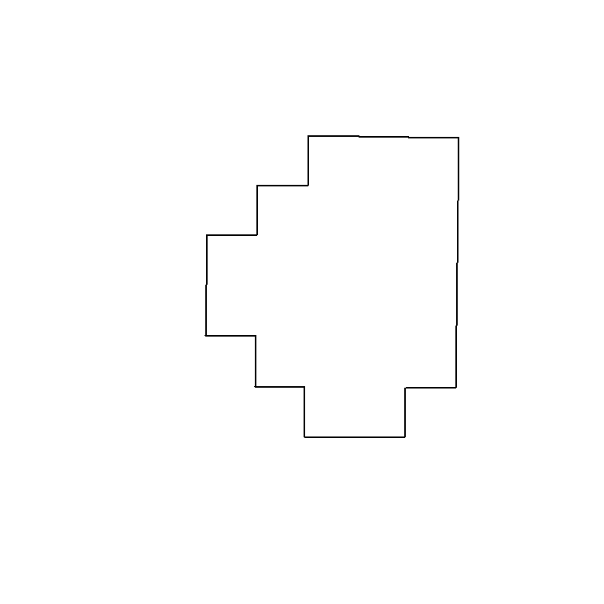

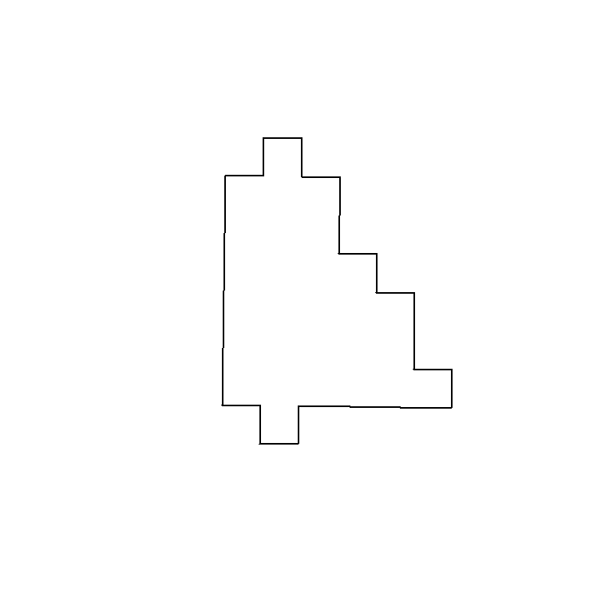

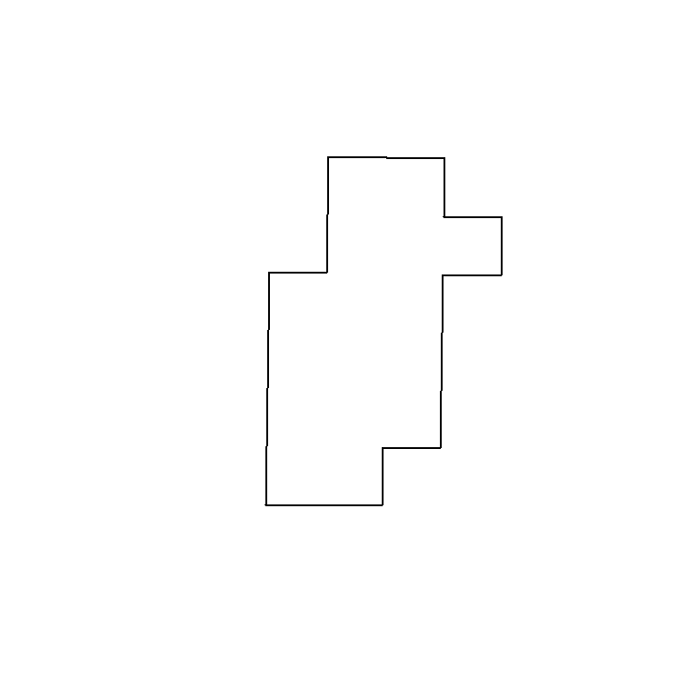

```r
plot(gs_crop@nodes$cellseg[1])
plot(gs_crop@nodes$cellseg[2])
plot(gs_crop@nodes$cellseg[3])
```

## 5.2 Combinar as primeiras vinte geometrias

`st_combine()` reúne as geometrias em uma única coleção sem dissolver os limites entre células. Assim, os vinte contornos continuam reconhecíveis no mesmo painel.

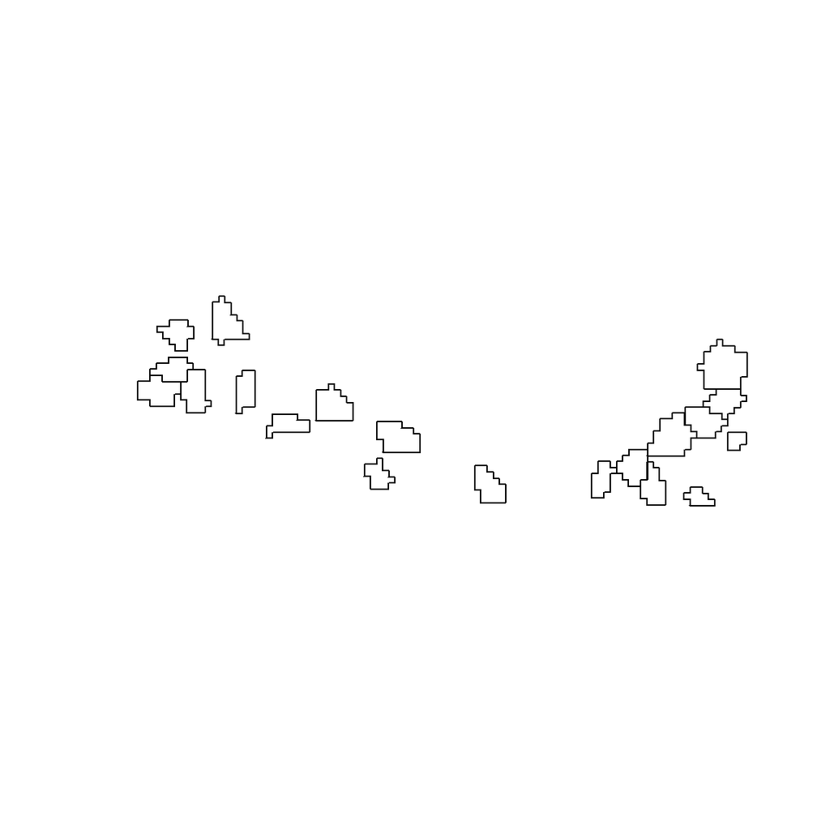

```r
plot(st_combine(gs_crop@nodes$cellseg[1:20]))
```

## 5.3 Visualização dos limites celulares sobre a imagem do tecido

Para que todos os painéis sejam comparáveis, todos utilizam a transformação `log2(x + 1)`, a mesma paleta e os mesmos limites de escala para a expressão de `PIGR`.

```r
cpal <- hcl.colors(100, palette = "Geyser", rev = FALSE)
data_range <- range(log2(gs_crop[["fdata"]] + 1))
```

Nesta resolução, os limites reais de segmentação celular podem ser traçados diretamente sobre a imagem do tecido, juntamente com os centroides dos nós. Neste gráfico, é possível observar o alinhamento correto entre a geometria e a imagem.

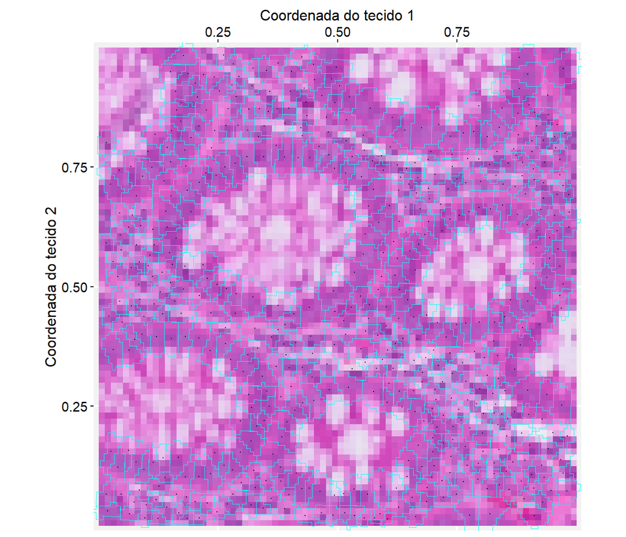

```r
p_nodes <- ggplot(gs_crop) +
  annotation_gspace_image(gs_crop, opacity = 1) +
  geom_sf( aes(geometry = cellseg), fill = NA,
    linewidth = 0.3, colour = "cyan") +
  geom_nodespace(colour = "black", size = 0.1, pch = 19) +
  scale_fill_continuous(palette = cpal, limits = data_range) +
  theme_gspace_coords(
    theme = "th3",is_norm = TRUE,
    xlab = "Coordenada do tecido 1",
    ylab = "Coordenada do tecido 2")
p_nodes
```

# 6 Comparar centros e polígonos celulares

## 6.1 Representar as células como vértices

No primeiro painel, cada célula é representada por um ponto localizado em seu centro. Essa forma compacta facilita a inspeção da distribuição espacial geral, mas não mostra o contorno celular.

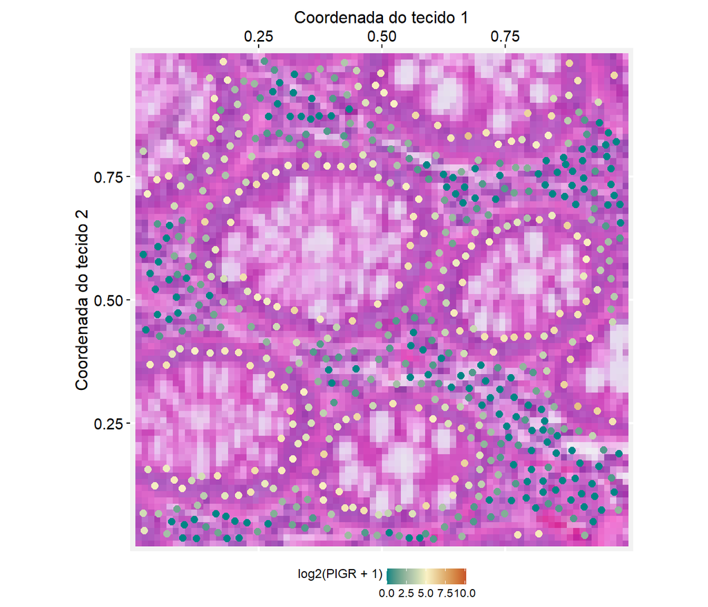

```r
p1 <- ggplot(gs_crop) +
  annotation_gspace_image(gs_crop, opacity = 1) +
  geom_nodespace(
    mapping = aes(colour = log2(PIGR + 1)),
    size = 1.5,pch = 19) +
  scale_colour_continuous(palette = cpal, limits = data_range) +
  theme_gspace_coords(
    theme = "th3",is_norm = TRUE,
    xlab = "Coordenada do tecido 1",
    ylab = "Coordenada do tecido 2")

p1
```

## 6.2 Representar as células como polígonos

No segundo painel, a expressão preenche o polígono de cada célula. Os centros são sobrepostos como pequenos pontos pretos para evidenciar a correspondência entre as duas representações.

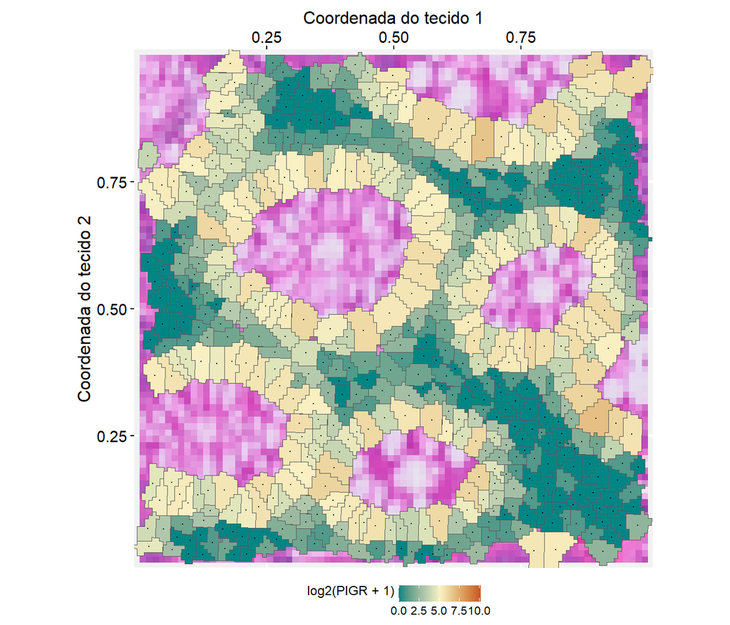

```r
p2 <- ggplot(gs_crop) +
  annotation_gspace_image(gs_crop, opacity = 1) +
  geom_sf(
    mapping = aes(
      geometry = cellseg,
      fill = log2(PIGR + 1))) +
  scale_fill_continuous(palette = cpal, limits = data_range) +
  geom_nodespace(colour = "black", size = 0.2, pch = 19) +
  theme_gspace_coords(
    theme = "th3",is_norm = TRUE,
    xlab = "Coordenada do tecido 1",
    ylab = "Coordenada do tecido 2")

p2
```

## 6.3 Colocar as representações lado a lado

O painel final resume a integração do RGraphSpace com as geometrias `sf`. A posição e a expressão são as mesmas nos dois lados; muda apenas a representação espacial de cada célula.

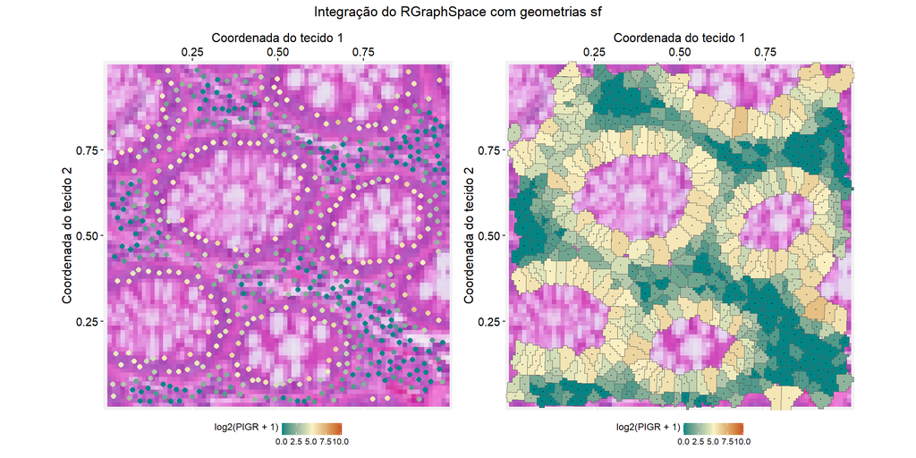

```r
p <- p1 + p2 +
  patchwork::plot_annotation(
    title = "Integração do RGraphSpace com geometrias sf",
    theme = theme(plot.title = element_text(hjust = 0.5)))
p
```

```r
ggsave(filename = file.path(diretorio_imagens, "SegCelular_GS_VisiumHD_PIGR.png"),
    plot = p,width = 9,height = 6,units = "in",dpi = 120,bg = "white")
```

# 7 Projeção do sinal com PathwaySpace

## 7.1 Rodando `PathwaySpace`

O objeto `PathwaySpace` é criado a partir do objeto `GraphSpace` utilizando a função `buildPathwaySpace()`. Antes de executar a projeção, precisamos especificar uma unidade de distância para a função de decaimento do sinal. Essa unidade afetará a extensão na qual o sinal é projetado no espaço de coordenadas. Utilizaremos a distância de centro a centro entre as geometrias.

```r
pspace_obj <- buildPathwaySpace(gs_crop, nrc = 700)
```

```
## Validating arguments...
## Creating a 'PathwaySpace' object...
```

```r
nspot <- getNearestNode(pspace_obj)
pdist <- mean(nspot$dist) # distância média
pdist
```

```
## [1] 0.02754154
```

Em seguida, é criado a silhueta do grafo para o objeto PathwaySpace. Podemos visualizar a silhueta em união com o `ggplot2`

```r
pspace_obj <- silhouetteMapping(pspace_obj, fill.cavity = FALSE, baseline = 0.03, pdist = max(nspot$dist))
```

```
## Validating arguments...
## Mapping graph silhouette...
## Mapping 'x' and 'y' coordinates...
## Silhouette: 77.54% of the landscape area!
```

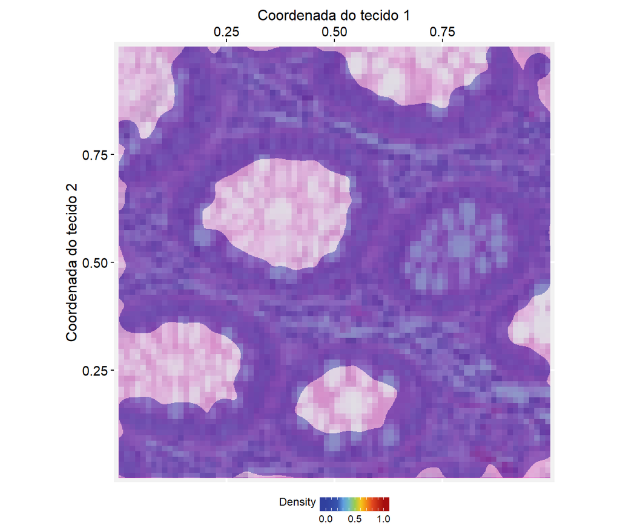

```r
ggplot(pspace_obj) +
  annotation_gspace_image(pspace_obj) +
  annotation_pspace_signal(pspace_obj, si.alpha = 0.5) +
  theme_gspace_coords(
    theme = "th3",is_norm = TRUE,
    xlab = "Coordenada do tecido 1",
    ylab = "Coordenada do tecido 2")
```